# GGIS 224 - Lab 5

xxx, Environmental Data Science @UIUC

2/x/2024

## Overview

In this lab you’ll explore a few questions on geometry operations using vector data, and you will be on your way to mastering the basics of unary and binary operations.

Before starting with these questions, you will need to go through *Chapter 5. Geometry Operations* in the textbook [Geocomputation in R](https://r.geocompx.org/geometry-operations.html). Feel free to skip Section 5.3 for now.

Don’t forget to comment your code while answering the questions below.

Render your completed RmD document by clicking on the “Knit” option in RStudio. Upload the .html file to your lab submission. Your uploaded .html file should follow this naming convention: Lab5_FirstNameInitial_LastName.html (for example, Lab5_E_Hall.html).

## Environment Setup

Load up all libraries needed for this lab.

*If you need to install rmapshaper and spDataLarge, make sure to recomment them before you knit your .Rmd for submission. The knitting will not work unless the install.packages lines of code are commented.*

```r
library(sf)
library(terra)
library(dplyr)
library(rmapshaper) #to use ms_simplify
library(spData) #data package needed for this chapter
library(spDataLarge) #data package needed for this chapter

#may need to install these two packages:
#install.packages("rmapshaper")
#install.packages("spDataLarge", repos = "https://nowosad.github.io/drat/", type = "source")
```

Load the necessary datasets for this lab.

```r
data("nz_height")
data("nz")
data("us_states")
```

## Explore and answer the following questions.

*Each question is worth 2 points - total 10 points*

Q1. Generate and plot simplified versions of the nz dataset. Experiment with different values of dTolerance (from 100 to 100,000) for st_simplify() and keep (ranging from 0.5 to 0.00005) for ms_simplify(). And answer the 3 questions (a, b, c) below:

1a) Using st_simplify(), at what ‘dTolerance’ value does the shape of New Zealand start to break down, making New Zealand unrecognizable? Hint: look at nrows() after each iteration to see if simplification is reducing row number. I have started exploring st_simplify() for you. Keep on changing the ‘dTolerance’ value to determine which number simplifies NZ too much and input that value below.

*dTolerance value = 100000*

```r
#Enter your code chunk that explores this question. Please leave comments as in detail as possible to show your logical development.

par(mfrow = c(1, 5)) # to layout maps beside each other

plot(st_geometry(nz), main = "Original", col = "white") #start with your basemap

# Simplify with dTolerance = 100
nz_st_simple_1 <- st_simplify(nz, dTolerance = 100) #use st_simplify to simply the NZ borders
plot(st_geometry(nz_st_simple_1), main = "dTolerance = 100", col = "red") #map those simplified borders
nrow(nz_st_simple_1) # 16 rows
```

```
## [1] 16
```

```r
#You can either add and plot multiple st_simplify objects with different dTolerance values and colors for comparison or continue to alter the one nz_st_simple_1 object.

# tolerance value = 1000
nz_st_simple_2 <- st_simplify(nz, dTolerance = 1000)  #use st_simplify to simply the NZ borders
plot(st_geometry(nz_st_simple_2), main = "dTolerance = 1000", col = "blue") #map those simplified borders
nrow(nz_st_simple_2) # 16 rows
```

```
## [1] 16
```

```r
# tolerance value = 10000
nz_st_simple_3 <- st_simplify(nz, dTolerance = 10000) #use st_simplify to simply the NZ borders
plot(st_geometry(nz_st_simple_3), main = "dTolerance = 10000", col = "green") #map those simplified borders
nrow(nz_st_simple_3) #16 rows
```

```
## [1] 16
```

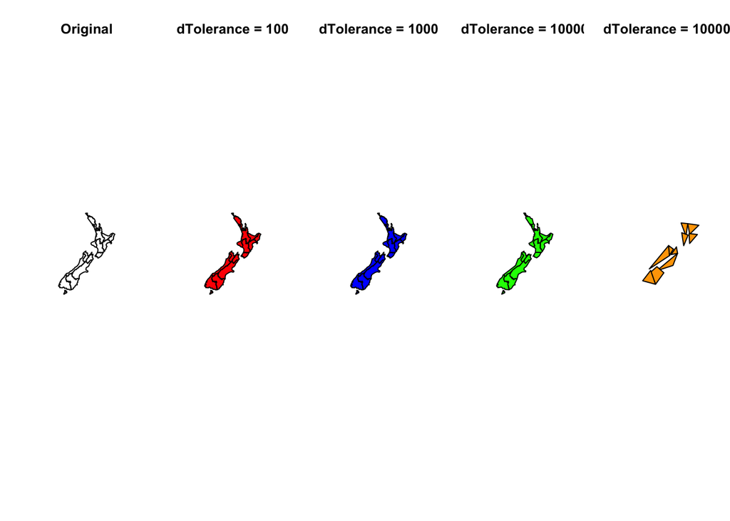

```r
# tolerance value = 100000
nz_st_simple_4 <- st_simplify(nz, dTolerance = 100000) #use st_simplify to simply the NZ borders
plot(st_geometry(nz_st_simple_4), main = "dTolerance = 100000", col = "orange") #map those simplified borders
```

```r
nrow(nz_st_simple_4) #16 rows
```

```
## [1] 16
```

```r
par(mfrow = c(1, 1))
```

1b) Using ms_simplify(), at what ‘keep’ value does the shape of New Zealand start to break down, making New Zealand unrecognizable? Using the same method as 1a, keep on changing the ‘keep’ value to determine which number simplifies NZ too much and input that value below. Refer to Q1 for the appropriate range of values to test.

*When keep is in the range of 0.00005 to 0.005*

```r
#explore ms_simplify() here: (ranging from 0.5 to 0.00005)

par(mfrow = c(1, 6)) # to layout maps beside each other

plot(st_geometry(nz), main = "Original", col = "white") #start with your basemap

# keep value = 0.5
nz_st_simple_5 <- ms_simplify(nz, keep = 0.5)
plot(st_geometry(nz_st_simple_5), main = "Keep = 0.5", col = "red")
nrow(nz_st_simple_5) # 16 rows
```

```
## [1] 16
```

```r
# keep value = 0.05
nz_st_simple_6 <- ms_simplify(nz, keep = 0.05)
plot(st_geometry(nz_st_simple_6), main = "Keep = 0.05", col = "blue")
nrow(nz_st_simple_6) # 16 rows
```

```
## [1] 16
```

```r
# keep value = 0.005
nz_st_simple_7 <- ms_simplify(nz, keep = 0.005)
plot(st_geometry(nz_st_simple_7), main = "Keep = 0.005", col = "green")
nrow(nz_st_simple_7) # 14 rows
```

```
## [1] 14
```

```r
# keep value = 0.0005
nz_st_simple_8 <- ms_simplify(nz, keep = 0.0005)
plot(st_geometry(nz_st_simple_8), main = "Keep = 0.0005", col = "orange")
nrow(nz_st_simple_8) # 14 rows
```

```
## [1] 14
```

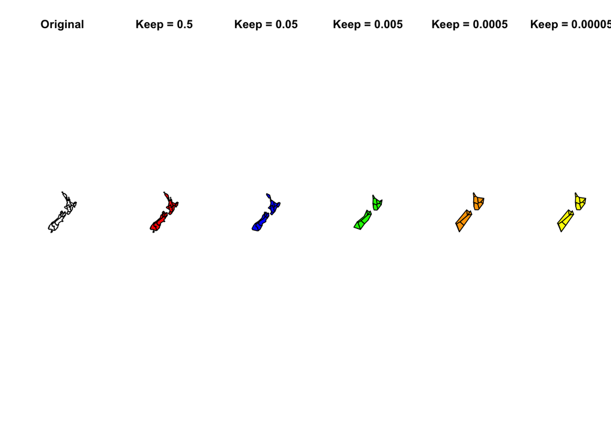

```r
# keep value = 0.00005
nz_st_simple_8 <- ms_simplify(nz, keep = 0.00005)
plot(st_geometry(nz_st_simple_8), main = "Keep = 0.00005", col = "yellow")
```

```r
nrow(nz_st_simple_8) # 14 rows
```

```
## [1] 14
```

1c) What is different about the results from st_simplify() compared with the results of ms_simplify()? What problems does this create and how can this be resolved? Refer to the reading (Chapter 5, section 5.2.1) to help you answer this question.

*The difference is that st_simplify() doesn’t lose the shape as quickly as ms_simplify(), we can see that when the the dTolerance value is 100000, the map drastically loses shape. However, for ms_simplify() the map loses shape starting from when keep value is 0.05 and there is no more resemblance when keep == 0.00005. Furthermore, even after hte dTolerance value is 100000 no rows are lost, on the other hand when keep is 0.005 the number of rows already reduced by 2 from 16 to 14. But, topology is lost with st_simplify() leading to holes in the map. Both of these methods of simplifacation can cause problems, which is the loss of detail, we can see from the maps when the keep value or dTolerance value reaches a certain threhold, the detail of the maps is significantly reduced. Especially, with the loss of topology from st_simplify() even more detail is loss. To resolve this, choose the optimal dTolerance and keep value to prevent loss of detail and oversimplification, and to preserve topology and preventing holes on the map, ms_simplify() may be more appropriate in some cases.*

Q2. In the first exercise in Chapter 4 (Spatial data operations), it was established that Canterbury region had 70 of the 101 highest points in New Zealand. Using st_buffer(), how many points in nz_height are within 100 km of Canterbury? Plot your results (Section 5.2.3 of reading). Step 1: Filter Canterbury from nz. Step 2: Double check that the coordinate system is in meters. Step 3: Set a 100km buffer surrounding Canterbury. Step 4: Subset how many nz high points are within the buffer. Step 5: Map it.

```r
#Enter your code chunk that explores this question. Please leave comments as in detail as possible to show your logical development.

# step 1: filter canterbury from nz
canterbury <- nz %>%
  filter(Name == "Canterbury")

# step 2: double check that the coordinate system is in meters
st_crs(canterbury) # already in meters
```

```
## Coordinate Reference System:
##   User input: EPSG:2193
##   wkt:
## PROJCS["NZGD2000 / New Zealand Transverse Mercator 2000",
##     GEOGCS["NZGD2000",
##         DATUM["New_Zealand_Geodetic_Datum_2000",
##             SPHEROID["GRS 1980",6378137,298.257222101,
##                 AUTHORITY["EPSG","7019"]],
##             TOWGS84[0,0,0,0,0,0,0],
##             AUTHORITY["EPSG","6167"]],
##         PRIMEM["Greenwich",0,
##             AUTHORITY["EPSG","8901"]],
##         UNIT["degree",0.0174532925199433,
##             AUTHORITY["EPSG","9122"]],
##         AUTHORITY["EPSG","4167"]],
##     PROJECTION["Transverse_Mercator"],
##     PARAMETER["latitude_of_origin",0],
##     PARAMETER["central_meridian",173],
##     PARAMETER["scale_factor",0.9996],
##     PARAMETER["false_easting",1600000],
##     PARAMETER["false_northing",10000000],
##     UNIT["metre",1,
##         AUTHORITY["EPSG","9001"]],
##     AUTHORITY["EPSG","2193"]]
```

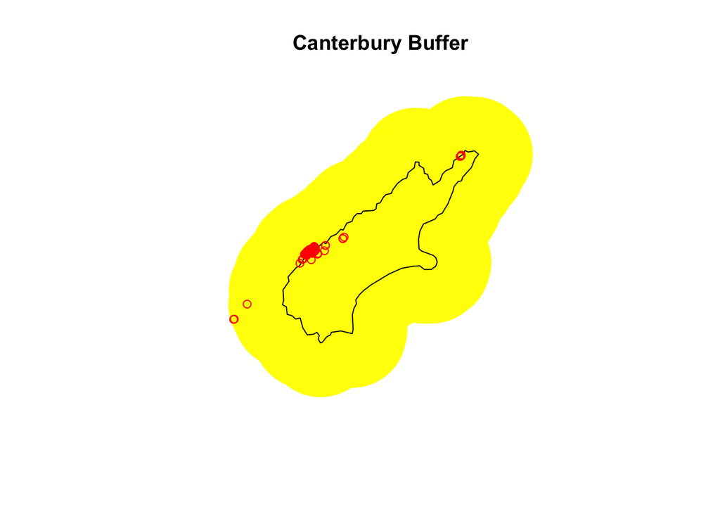

```r
# step 3: set a 100km buffer surrounding Canterbury
canterbury_buffer <- st_buffer(canterbury, dist = 100000)

# step 4: subset how many nz high points are within the buffer
intersects <- st_intersects(nz_height, canterbury_buffer, sparse = FALSE)
nz_height_within_buffer <- nz_height[intersects, ]

# step 5: map it
plot(st_geometry(canterbury_buffer), col = 'yellow', main = "Canterbury Buffer", border = NA) # plotting the buffer
plot(st_geometry(canterbury), border = 'black', add = TRUE) # plot the base Canterbury region
plot(st_geometry(nz_height_within_buffer), col = 'red', add = TRUE) # plotting the high points
```

```r
# number of points
print(nrow(nz_height_within_buffer)) # 95 points
```

```
## [1] 95
```

How many points in nz_height are within 100 km of Canterbury?

*95*

Q3. How far is the geographic centroid of Canterbury from the centroid of New Zealand?

1. Using st_centroid() (Section 5.2.2), find the geographic centroid of New Zealand. Notice that ‘st_centroid(nz)’ outputs the centroid of each region. Use a function to combine all the regions to only get one centroid point for the whole country (Hint: section 5.2.7). Map the result.

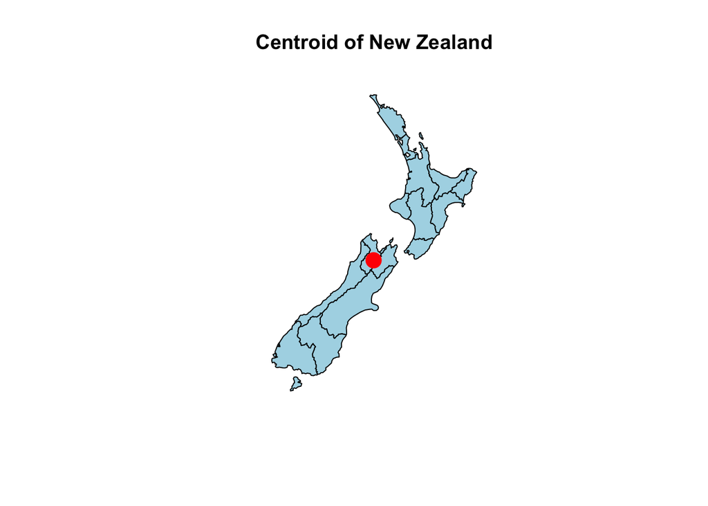

```r
#Enter your code chunk that solves this question. Please leave comments as in detail as possible to show your logical development.

# combining all regions into one feature using st_union
nz_combined <- st_union(nz)

# calculating the centroid of the combined feature
nz_centroid <- st_centroid(nz_combined)

# plotting the map to visualize the centroid on the map of New Zealand
plot(st_geometry(nz), col = 'lightblue', main = "Centroid of New Zealand")
plot(st_geometry(nz_centroid), col = 'red', add = TRUE, pch = 20, cex = 3)
```

2. Find the distance from the NZ centroid from the geographic centroid of Canterbury.

```r
# calculating the centroid of Canterbury
canterbury_centroid <- st_centroid(canterbury)
# combining all regions into one feature using st_union
nz_combined <- st_union(nz)

# calculating the centroid of the combined feature
nz_centroid <- st_centroid(nz_combined)

# find the distance between the centroid of Canterbury and the centroid of New Zealand
distance <- st_distance(canterbury_centroid, nz_centroid)

# display the distance / result
print(distance)
```

```
## Units: [m]
##          [,1]
## [1,] 234192.6
```

*234192.6 meters*

In order to answer Q4, go over this example from the reading, section 5.2.5 on how to create circles. **This is an example, no need to add code to this chunk.**

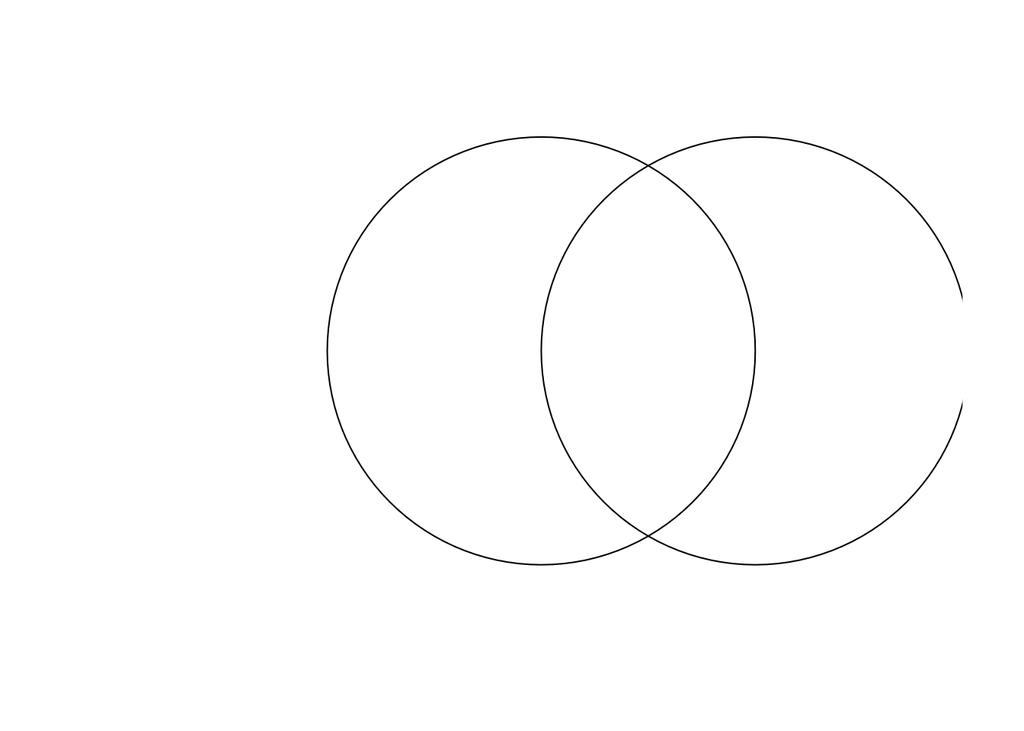

```r
#First we create 2 points, where 0,1 and 1,1 are its location. These are the center points of our circles
a = st_sfc(st_point(c(0, 1)))
b = st_sfc(st_point(c(1, 1)))
#then we convert the center points into circles with a radius of 1 and can plot them
a_circle = st_buffer(a, dist = 1)
b_circle = st_buffer(b, dist = 1)
plot(a_circle)
plot(b_circle, add=TRUE)
```

Q4. Using what you learned in the above code chunk, generate a circle with a center of (0,0) and a radius of 5, and then another circle with a center of (7,1) and a radius of 6. Follow the code examples in section 5.2.6 to generate 40 points that are randomly distributed in the bounding box of the two circles. Then subset the points that are contained within both circles.

Use two methods to subset the points: (1) using the spatial predicate st_intersects() and (2) using the binary operation st_intersection() .

Make a plot showing the two circles, your 40 random points, and the highlighted points within both circles.

BONUS (+1 pt): Display both methods for subsetting the points on the same plot. Make sure they are both visible and can be differenciated even though they display the same information.

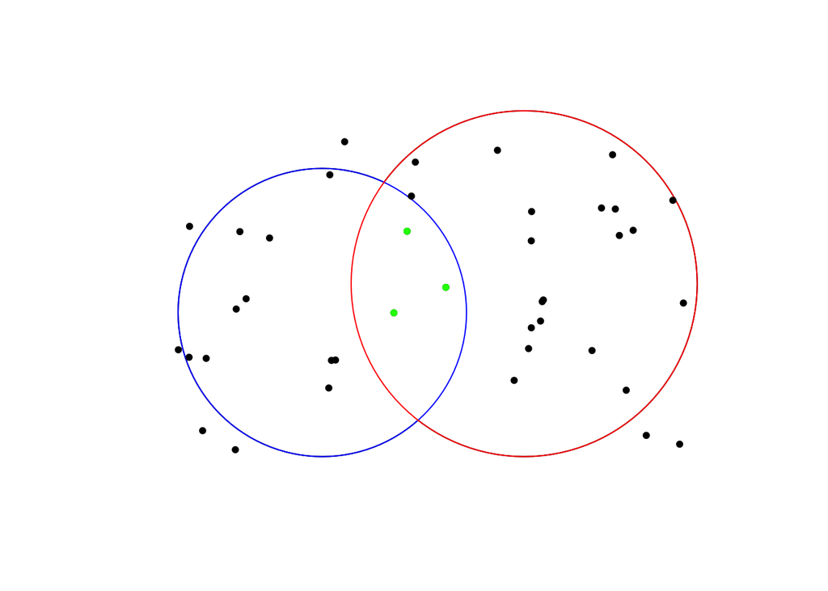

```r
#Enter your code chunk that solves this question. Please leave comments as in detail as possible to show your logical development.

# create 2 points based on the parameters given
point1 <- st_sfc(st_point(c(0, 0)))
point2 <- st_sfc(st_point(c(7, 1)))

# creating circles of the 2 points
circle1 <- st_buffer(point1, dist = 5)
circle2 <- st_buffer(point2, dist = 6)

# combining the 2 circles
combined_circles <- st_union(circle1, circle2)

# finding the bounding box
bbox <- st_bbox(combined_circles)

# generate random points
set.seed(2024)
points <- st_sample(x = st_as_sfc(bbox), size = 40, type = "random")

# use st_intersects to find which points intersect with each circle
intersects_circle1 <- st_intersects(points, circle1)
intersects_circle2 <- st_intersects(points, circle2)
points_in_both <- lengths(intersects_circle1) > 0 & lengths(intersects_circle2) > 0
indices_in_both <- which(points_in_both)
points_df <- st_as_sf(points) %>%
  mutate(index = row_number()) %>%
  filter(index %in% indices_in_both)

# plot the circles and the points
plot(st_geometry(combined_circles)) # plotting combined circles
plot(st_geometry(circle1), border = "blue", add = TRUE) # plotting first circle
plot(st_geometry(circle2), border = "red", add = TRUE) # plotting second circle
plot(st_geometry(points), col = "black", pch = 20, add = TRUE) # plotting random points as circles filled in black
plot(st_geometry(points_df), col = "green", pch = 20, add = TRUE) # highlighting points in green that lies in the intersection
```

Q5. Calculate the length of the boundary lines of US states in meters. Which state has the longest border and which has the shortest? Hint: The st_length function only computes the length of LINESTRING or MULTILINESTRING geometries. Step 1: First make us_states geometry compatible with st_length - it is currently a POLYGON. Step 2: Calculate state line length as a new object. Step 3: Assign state lengths to a new attribute in us_states. Step 4: Order by border length so you can see which state has the longest and the shortest. border lengths. Hint: https://dplyr.tidyverse.org/reference/slice.html.

```r
#Enter your code chunk that solves this question. Please leave comments as in detail as possible to show your logical development.

# step 1: First make us_states geometry compatible with st_length - it is currently a POLYGON.
us_states_lines <- st_boundary(us_states)

# step 2: Calculate state line length as a new object.
state_lengths <- st_length(us_states_lines)

# step 3: Assign state lengths to a new attribute in us_states.
us_states$border_length <- state_lengths

# step 4: Order by border length so you can see which state has the longest and the shortest border lengths.
ordered_states <- us_states %>%
  arrange(border_length) %>%
  select(NAME, border_length)

# finding longest and shortest border
shortest <- head(ordered_states, 1)
longest <- tail(ordered_states, 1)

# printing the values using the correct column name for state names
print(paste("Shortest border state:", shortest$NAME))
```

```
## [1] "Shortest border state: District of Columbia"
```

```r
print(paste("Longest border state:", longest$NAME))
```

```
## [1] "Longest border state: Texas"
```

Which state has the longest border and which has the shortest?

*Longest border = Texas, shortest border = District of Columbia*

Render your document by clicking on the “Knit” option in RStudio. Upload the .html file to your assignment submission!

.